# ezBIDS CLI Demo: UK Biobank Example DICOMs

This notebook demonstrates converting DICOM data to BIDS format using `ezbids-cli`.

Data source: [UK Biobank Example DICOMs](https://biobank.ndph.ox.ac.uk/ukb/label.cgi?id=507)

## 1. Setup

Install dependencies and configure working directories.

```python
# Install ezbids-cli (uncomment one option)
# !pip install ezbids-cli  # From PyPI
!pip install -e .. --quiet  # From local source (development)

# Install visualization dependencies
!pip install nibabel matplotlib --quiet
```

```python
import json
import shutil
import zipfile
from pathlib import Path
from urllib.request import urlretrieve

import matplotlib.pyplot as plt
import nibabel as nib
import numpy as np

# Working directories
WORK_DIR = Path("demo_data")
DICOM_DIR = WORK_DIR / "dicoms"
BIDS_DIR = WORK_DIR / "bids_output"
ANALYSIS_DIR = WORK_DIR / "analysis"

for d in [WORK_DIR, DICOM_DIR, ANALYSIS_DIR]:
    d.mkdir(exist_ok=True)

print(f"Working directory: {WORK_DIR.absolute()}")
```

```
Working directory: /home/runner/work/ezbids-cli/ezbids-cli/notebooks/demo_data
```

## 2. Download UK Biobank Example DICOMs

UK Biobank provides publicly accessible example DICOM datasets. We'll download five modalities to demonstrate multi-modal conversion:

[output not shown]

```python
# UK Biobank example DICOM URLs
UKB_EXAMPLES = {
    "t1": "https://biobank.ndph.ox.ac.uk/ukb/ukb/examples/eg_brain_t1.zip",
    "t2flair": "https://biobank.ndph.ox.ac.uk/ukb/ukb/examples/eg_brain_t2flair.zip",
    "rest_fmri": "https://biobank.ndph.ox.ac.uk/ukb/ukb/examples/eg_brain_rest.zip",
    "dwi": "https://biobank.ndph.ox.ac.uk/ukb/ukb/examples/eg_brain_mbdif.zip",
    "swi": "https://biobank.ndph.ox.ac.uk/ukb/ukb/examples/eg_brain_suswt.zip",
}

def download_and_extract(name: str, url: str, target_dir: Path) -> Path:
    """Download and extract a zip file."""
    zip_path = target_dir / f"{name}.zip"
    extract_dir = target_dir / name

    if extract_dir.exists():
        print(f"  {name}: already exists, skipping")
        return extract_dir

    print(f"  {name}: downloading...", end=" ", flush=True)
    urlretrieve(url, zip_path)

    print("extracting...", end=" ", flush=True)
    with zipfile.ZipFile(zip_path, 'r') as zf:
        zf.extractall(extract_dir)
    zip_path.unlink()

    file_count = sum(1 for f in extract_dir.rglob("*") if f.is_file())
    print(f"done ({file_count} files)")
    return extract_dir
```

```python
# Download all five modalities
datasets_to_download = ["t1", "t2flair", "swi", "rest_fmri", "dwi"]

print("Downloading UK Biobank example DICOMs...\n")
for name in datasets_to_download:
    download_and_extract(name, UKB_EXAMPLES[name], DICOM_DIR)

print("\nDownload complete!")
```

```
Downloading UK Biobank example DICOMs...

  t1: downloading...
```

```
extracting...
```

```
done (417 files)
  t2flair: downloading...
```

```
extracting...
```

```
done (385 files)
  swi: downloading...
```

```
extracting...
```

```
done (6433 files)
  rest_fmri: downloading...
```

```
extracting...
```

```
done (492 files)
  dwi: downloading...
```

```
extracting...
```

```
done (611 files)

Download complete!
```

```python
# Show what we downloaded
print("Downloaded DICOM directories:")
print("=" * 40)
for d in sorted(DICOM_DIR.iterdir()):
    if d.is_dir():
        file_count = sum(1 for f in d.rglob("*") if f.is_file())
        print(f"  {d.name}/ ({file_count} files)")
```

```
Downloaded DICOM directories:
========================================
  dwi/ (611 files)
  rest_fmri/ (492 files)
  swi/ (6433 files)
  t1/ (417 files)
  t2flair/ (385 files)
```

## 3. One-Command Conversion

The simplest way to use ezbids-cli: a single command that handles everything.

```
ezbids convert <input_dir> --output-dir <output_dir>
```

This will:

1. Discover all DICOM files
2. Convert to NIfTI using dcm2niix
3. Identify datatypes and suffixes (T1w, FLAIR, bold, dwi, etc.)
4. Extract BIDS entities (task, direction, run, etc.)
5. Organize into BIDS directory structure
6. Validate the result

```python
# Clean previous output if it exists
if BIDS_DIR.exists():
    shutil.rmtree(BIDS_DIR)

# Run the conversion
!ezbids convert {DICOM_DIR} --output-dir {BIDS_DIR}
```

```
Converting: demo_data/dicoms
Output: demo_data/bids_output
Step 1/2: Analyzing data...
Step 1/4: Discovering files...
```

```
DICOM files detected, running dcm2niix...
Running: /usr/bin/dcm2niix -z y -f time-%t-sn-%s -o
demo_data/bids_output/.ezbids_work/nifti -d 9 -ba n demo_data/dicoms
```

```
Converted 20 files
Found 20 NIfTI files
Step 2/4: Organizing dataset...
Step 3/4: Identifying datatypes and suffixes...
Step 4/4: Extracting entity labels...
```

```
Analysis saved to demo_data/bids_output/.ezbids_work/ezBIDS_core.json
Step 2/2: Converting to BIDS...
Creating BIDS dataset: demo_data/bids_output/dataset
BIDS dataset created: demo_data/bids_output/dataset
Validating BIDS output...
```

```
✗ Validation errors found (44 files checked)
  • Invalid BIDS filename:
/sub-01/fmap/sub-01_dir-RL_echo-1_part-mag_magnitude1.nii.gz
  • Invalid BIDS filename:
/sub-01/fmap/sub-01_dir-RL_run-02_echo-2_part-mag_magnitude2.json
  • Invalid BIDS filename: /sub-01/fmap/sub-01_echo-1_part-phase_phase1.nii.gz
  • Invalid BIDS filename:
/sub-01/fmap/sub-01_dir-RL_run-02_echo-1_part-mag_magnitude1.nii.gz
  • Invalid BIDS filename:
/sub-01/fmap/sub-01_dir-RL_echo-1_part-phase_phase1.json
  • Invalid BIDS filename: /sub-01/fmap/sub-01_echo-2_part-mag_magnitude2.json
  • Invalid BIDS filename:
/sub-01/fmap/sub-01_echo-2_part-phase_phasediff.nii.gz
  • Invalid BIDS filename: /sub-01/fmap/sub-01_echo-1_part-mag_magnitude1.json
  • Invalid BIDS filename: /sub-01/fmap/sub-01_echo-1_part-mag_magnitude1.nii.gz
  • Invalid BIDS filename: /sub-01/fmap/sub-01_echo-2_part-phase_phasediff.json
  • Invalid BIDS filename:
/sub-01/fmap/sub-01_dir-RL_echo-2_part-phase_phasediff.json
  • Invalid BIDS filename: /sub-01/fmap/sub-01_echo-2_part-mag_magnitude2.nii.gz
  • Invalid BIDS filename:
/sub-01/fmap/sub-01_dir-RL_echo-2_part-phase_phasediff.nii.gz
  • Invalid BIDS filename:
/sub-01/fmap/sub-01_dir-RL_echo-2_part-mag_magnitude2.json
  • Invalid BIDS filename:
/sub-01/fmap/sub-01_dir-RL_run-02_echo-1_part-mag_magnitude1.json
  • Invalid BIDS filename:
/sub-01/fmap/sub-01_dir-RL_run-02_echo-2_part-mag_magnitude2.nii.gz
  • Invalid BIDS filename: /sub-01/fmap/sub-01_echo-1_part-phase_phase1.json
  • Invalid BIDS filename:
/sub-01/fmap/sub-01_dir-RL_echo-1_part-phase_phase1.nii.gz
  • Invalid BIDS filename:
/sub-01/fmap/sub-01_dir-RL_echo-1_part-mag_magnitude1.json
  • Invalid BIDS filename:
/sub-01/fmap/sub-01_dir-RL_echo-2_part-mag_magnitude2.nii.gz
Conversion complete: demo_data/bids_output
```

```python
# Display the resulting BIDS structure
def show_tree(path: Path, prefix: str = "", max_depth: int = 4, current_depth: int = 0):
    """Display directory tree."""
    if current_depth >= max_depth:
        return

    items = sorted(path.iterdir())
    for i, item in enumerate(items):
        is_last = i == len(items) - 1
        connector = "\u2514\u2500\u2500 " if is_last else "\u251c\u2500\u2500 "
        print(f"{prefix}{connector}{item.name}")

        if item.is_dir():
            extension = "    " if is_last else "\u2502   "
            show_tree(item, prefix + extension, max_depth, current_depth + 1)

print("BIDS Output Structure")
print("=" * 50)
if BIDS_DIR.exists():
    show_tree(BIDS_DIR)
else:
    print("No output yet - run the conversion cell above")
```

```
BIDS Output Structure
==================================================
├── .ezbids_work
│   ├── ezBIDS_core.json
│   └── nifti
│       ├── time-20180719151557-sn-10.json
│       ├── time-20180719151557-sn-10.nii.gz
│       ├── time-20180719151557-sn-11.json
│       ├── time-20180719151557-sn-11.nii.gz
│       ├── time-20180719151557-sn-12.bval
│       ├── time-20180719151557-sn-12.bvec
│       ├── time-20180719151557-sn-12.json
│       ├── time-20180719151557-sn-12.nii.gz
│       ├── time-20180719151557-sn-13.json
│       ├── time-20180719151557-sn-13.nii.gz
│       ├── time-20180719151557-sn-14.bval
│       ├── time-20180719151557-sn-14.bvec
│       ├── time-20180719151557-sn-14.json
│       ├── time-20180719151557-sn-14.nii.gz
│       ├── time-20180719151557-sn-15_cH31_e2.json
│       ├── time-20180719151557-sn-15_cH31_e2.nii.gz
│       ├── time-20180719151557-sn-15_cH8_e1.json
│       ├── time-20180719151557-sn-15_cH8_e1.nii.gz
│       ├── time-20180719151557-sn-16_e1.json
│       ├── time-20180719151557-sn-16_e1.nii.gz
│       ├── time-20180719151557-sn-16_e2.json
│       ├── time-20180719151557-sn-16_e2.nii.gz
│       ├── time-20180719151557-sn-17_e1.json
│       ├── time-20180719151557-sn-17_e1.nii.gz
│       ├── time-20180719151557-sn-17_e2.json
│       ├── time-20180719151557-sn-17_e2.nii.gz
│       ├── time-20180719151557-sn-18_cH20_e2_ph.json
│       ├── time-20180719151557-sn-18_cH20_e2_ph.nii.gz
│       ├── time-20180719151557-sn-18_cH24_e1_ph.json
│       ├── time-20180719151557-sn-18_cH24_e1_ph.nii.gz
│       ├── time-20180719151557-sn-19_e1_ph.json
│       ├── time-20180719151557-sn-19_e1_ph.nii.gz
│       ├── time-20180719151557-sn-19_e2_ph.json
│       ├── time-20180719151557-sn-19_e2_ph.nii.gz
│       ├── time-20180719151557-sn-5.json
```

[output cut: 45 more lines]

```
        │   ├── sub-01_dir-RL_run-02_echo-2_part-mag_magnitude2.json
        │   ├── sub-01_dir-RL_run-02_echo-2_part-mag_magnitude2.nii.gz
        │   ├── sub-01_echo-1_part-mag_magnitude1.json
        │   ├── sub-01_echo-1_part-mag_magnitude1.nii.gz
        │   ├── sub-01_echo-1_part-phase_phase1.json
        │   ├── sub-01_echo-1_part-phase_phase1.nii.gz
        │   ├── sub-01_echo-2_part-mag_magnitude2.json
        │   ├── sub-01_echo-2_part-mag_magnitude2.nii.gz
        │   ├── sub-01_echo-2_part-phase_phasediff.json
        │   └── sub-01_echo-2_part-phase_phasediff.nii.gz
        └── func
            ├── sub-01_task-rest_acq-mb8_part-mag_bold.json
            ├── sub-01_task-rest_acq-mb8_part-mag_bold.nii.gz
            ├── sub-01_task-rest_acq-mb8_part-mag_sbref.json
            └── sub-01_task-rest_acq-mb8_part-mag_sbref.nii.gz
```

### Visualize the Converted Data

Let's view the converted NIfTI files:

```python
# Find all NIfTI files in the BIDS output
nifti_files = sorted(BIDS_DIR.rglob("*.nii.gz"))

print("Converted NIfTI files:")
print("-" * 60)
for f in nifti_files:
    # Show path relative to BIDS dir
    rel_path = f.relative_to(BIDS_DIR)
    # Get image dimensions
    img = nib.load(f)
    shape = img.shape
    print(f"  {rel_path}  {shape}")
```

```
Converted NIfTI files:
------------------------------------------------------------
  .ezbids_work/nifti/time-20180719151557-sn-10.nii.gz  (192, 256, 256)
  .ezbids_work/nifti/time-20180719151557-sn-11.nii.gz  (104, 104, 72)
  .ezbids_work/nifti/time-20180719151557-sn-12.nii.gz  (104, 104, 72, 6)
  .ezbids_work/nifti/time-20180719151557-sn-13.nii.gz  (104, 104, 72)
  .ezbids_work/nifti/time-20180719151557-sn-14.nii.gz  (104, 104, 72, 105)
  .ezbids_work/nifti/time-20180719151557-sn-15_cH31_e2.nii.gz  (256, 288, 48, 32)
  .ezbids_work/nifti/time-20180719151557-sn-15_cH8_e1.nii.gz  (256, 288, 48, 32)
  .ezbids_work/nifti/time-20180719151557-sn-16_e1.nii.gz  (256, 288, 48)
  .ezbids_work/nifti/time-20180719151557-sn-16_e2.nii.gz  (256, 288, 48)
  .ezbids_work/nifti/time-20180719151557-sn-17_e1.nii.gz  (256, 288, 48)
  .ezbids_work/nifti/time-20180719151557-sn-17_e2.nii.gz  (256, 288, 48)
  .ezbids_work/nifti/time-20180719151557-sn-18_cH20_e2_ph.nii.gz  (256, 288, 48, 32)
  .ezbids_work/nifti/time-20180719151557-sn-18_cH24_e1_ph.nii.gz  (256, 288, 48, 32)
  .ezbids_work/nifti/time-20180719151557-sn-19_e1_ph.nii.gz  (256, 288, 48)
  .ezbids_work/nifti/time-20180719151557-sn-19_e2_ph.nii.gz  (256, 288, 48)
  .ezbids_work/nifti/time-20180719151557-sn-5.nii.gz  (208, 256, 256)
  .ezbids_work/nifti/time-20180719151557-sn-6.nii.gz  (208, 256, 256)
  .ezbids_work/nifti/time-20180719151557-sn-7.nii.gz  (88, 88, 64)
  .ezbids_work/nifti/time-20180719151557-sn-8.nii.gz  (88, 88, 64, 490)
  .ezbids_work/nifti/time-20180719151557-sn-9.nii.gz  (192, 256, 256)
  dataset/sub-01/anat/sub-01_part-mag_FLAIR.nii.gz  (192, 256, 256)
  dataset/sub-01/anat/sub-01_part-mag_T1w.nii.gz  (208, 256, 256)
  dataset/sub-01/anat/sub-01_run-02_part-mag_FLAIR.nii.gz  (192, 256, 256)
  dataset/sub-01/anat/sub-01_run-02_part-mag_T1w.nii.gz  (208, 256, 256)
  dataset/sub-01/dwi/sub-01_acq-mb3_dwi.nii.gz  (104, 104, 72, 105)
  dataset/sub-01/fmap/sub-01_acq-mb3_dir-AP_epi.nii.gz  (104, 104, 72, 6)
  dataset/sub-01/fmap/sub-01_dir-RL_echo-1_part-mag_magnitude1.nii.gz  (256, 288, 48)
```

```
  dataset/sub-01/fmap/sub-01_dir-RL_echo-1_part-phase_phase1.nii.gz  (256, 288, 48)
  dataset/sub-01/fmap/sub-01_dir-RL_echo-2_part-mag_magnitude2.nii.gz  (256, 288, 48)
  dataset/sub-01/fmap/sub-01_dir-RL_echo-2_part-phase_phasediff.nii.gz  (256, 288, 48)
  dataset/sub-01/fmap/sub-01_dir-RL_run-02_echo-1_part-mag_magnitude1.nii.gz  (256, 288, 48)
  dataset/sub-01/fmap/sub-01_dir-RL_run-02_echo-2_part-mag_magnitude2.nii.gz  (256, 288, 48)
  dataset/sub-01/fmap/sub-01_echo-1_part-mag_magnitude1.nii.gz  (256, 288, 48, 32)
  dataset/sub-01/fmap/sub-01_echo-1_part-phase_phase1.nii.gz  (256, 288, 48, 32)
  dataset/sub-01/fmap/sub-01_echo-2_part-mag_magnitude2.nii.gz  (256, 288, 48, 32)
  dataset/sub-01/fmap/sub-01_echo-2_part-phase_phasediff.nii.gz  (256, 288, 48, 32)
  dataset/sub-01/func/sub-01_task-rest_acq-mb8_part-mag_bold.nii.gz  (88, 88, 64, 490)
  dataset/sub-01/func/sub-01_task-rest_acq-mb8_part-mag_sbref.nii.gz  (88, 88, 64)
```

```python
def plot_slices(nifti_path, title=None, vol_idx=0):
    """Plot orthogonal slices from a NIfTI file."""
    img = nib.load(nifti_path)
    data = img.get_fdata()

    # Handle 4D data by selecting a volume
    if data.ndim == 4:
        data = data[..., vol_idx]
        title_suffix = f" (vol {vol_idx})"
    else:
        title_suffix = ""

    # Get middle slices
    mid_x, mid_y, mid_z = [s // 2 for s in data.shape[:3]]

    fig, axes = plt.subplots(1, 3, figsize=(12, 4))

    axes[0].imshow(np.rot90(data[mid_x, :, :]), cmap='gray')
    axes[0].set_title('Sagittal')
    axes[0].axis('off')

    axes[1].imshow(np.rot90(data[:, mid_y, :]), cmap='gray')
    axes[1].set_title('Coronal')
    axes[1].axis('off')

    axes[2].imshow(np.rot90(data[:, :, mid_z]), cmap='gray')
    axes[2].set_title('Axial')
    axes[2].axis('off')

    if title:
        fig.suptitle(f"{title}{title_suffix}", fontsize=12)

    plt.tight_layout()
    plt.show()
```

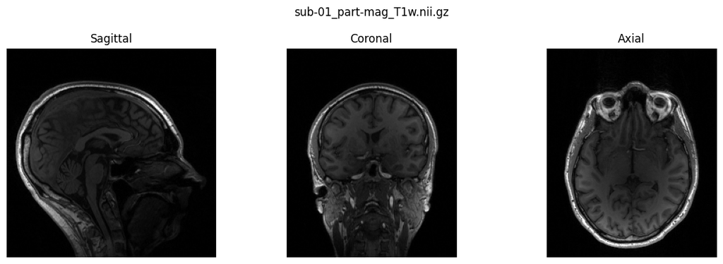

```python
# View the T1w anatomical scan
t1_files = [f for f in nifti_files if "T1w" in f.name]
if t1_files:
    plot_slices(t1_files[0], title=t1_files[0].name)
```

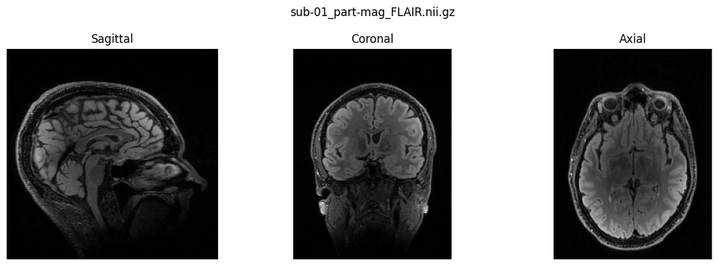

```python
# View the FLAIR scan
flair_files = [f for f in nifti_files if "FLAIR" in f.name]
if flair_files:
    plot_slices(flair_files[0], title=flair_files[0].name)
```

```python
# View the SWI scan (T2*-weighted)
swi_files = [f for f in nifti_files if "T2starw" in f.name]
if swi_files:
    plot_slices(swi_files[0], title=swi_files[0].name)
```

[output not shown]

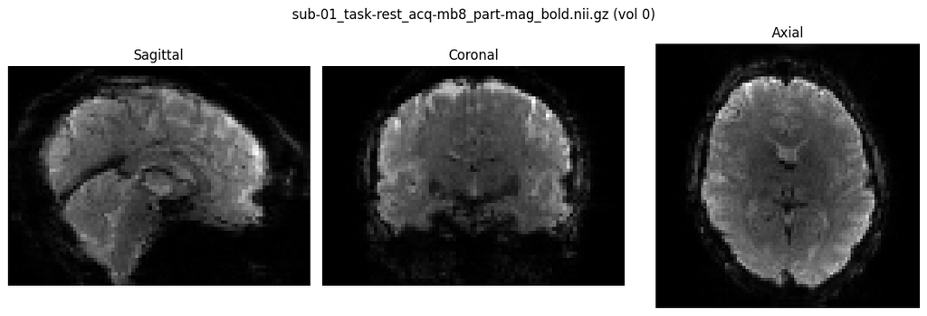

```python
# View the resting-state fMRI (first volume of 4D)
bold_files = [f for f in nifti_files if "bold" in f.name]
if bold_files:
    plot_slices(bold_files[0], title=bold_files[0].name, vol_idx=0)
```

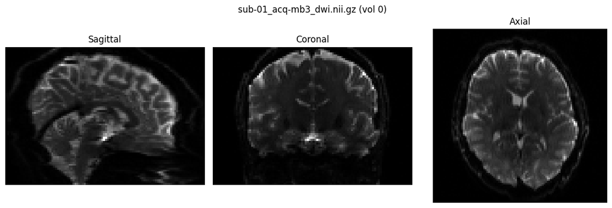

```python
# View the DWI scan (first volume of 4D)
dwi_files = [f for f in nifti_files if f.name.endswith("_dwi.nii.gz")]
if dwi_files:
    plot_slices(dwi_files[0], title=dwi_files[0].name, vol_idx=0)
```

## 4. Understanding What Was Detected

Let's use the programmatic API to understand exactly what ezbids detected and how it made its decisions.

```python
from ezbids_cli.core.analyzer import Analyzer

# Run analysis (without conversion) to inspect what was detected
analyzer = Analyzer(DICOM_DIR, ANALYSIS_DIR)
analysis = analyzer.analyze()

print(f"Analysis Summary")
print("=" * 50)
print(f"Subjects found: {len(analysis.get('subjects', []))}")
print(f"Acquisitions found: {len(analysis.get('objects', []))}")
```

```
Step 1/4: Discovering files...
```

```
DICOM files detected, running dcm2niix...
```

```
Running: /usr/bin/dcm2niix -z y -f time-%t-sn-%s -o demo_data/analysis/nifti -d 9 -ba n demo_data/dicoms
```

```
Converted 20 files
```

```
Found 20 NIfTI files
```

```
Step 2/4: Organizing dataset...
```

```
Step 3/4: Identifying datatypes and suffixes...
```

```
Step 4/4: Extracting entity labels...
```

```
Analysis saved to demo_data/analysis/ezBIDS_core.json
```

```
Analysis Summary
==================================================
Subjects found: 1
Acquisitions found: 20
```

```python
# Show detailed detection results for each acquisition
print("Detected Acquisitions")
print("=" * 70)

for i, obj in enumerate(analysis.get("objects", []), 1):
    datatype = obj.get("datatype", "unknown")
    suffix = obj.get("suffix", "unknown")
    bids_type = f"{datatype}/{suffix}" if datatype and suffix else "unidentified"
    entities = obj.get("entities", {})
    series_desc = obj.get("SeriesDescription", "N/A")

    print(f"\n[{i}] {bids_type}")
    print(f"    Series: {series_desc}")

    # Show extracted entities
    entity_items = [(k, v) for k, v in entities.items() if k not in ["subject", "session"] and v]
    if entity_items:
        entity_str = ", ".join(f"{k}={v}" for k, v in entity_items)
        print(f"    Entities: {entity_str}")

    # Show any messages or warnings
    if obj.get("message"):
        print(f"    Note: {obj['message']}")
```

```
Detected Acquisitions
======================================================================

[1] anat/T1w
    Series: T1_p2_1mm_fov256_sag_TI_880
    Entities: part=mag
    Note: Identified as anat/T1w

[2] anat/T1w
    Series: T1_p2_1mm_fov256_sag_TI_880
    Entities: part=mag
    Note: Identified as anat/T1w

[3] func/bold
    Series: MB8_FMRI_fov210_2.4mm_resting
    Entities: task=rest, acquisition=mb8, part=mag
    Note: Identified as func/bold

[4] func/sbref
    Series: MB8_FMRI_fov210_2.4mm_resting_SBRef
    Entities: task=rest, acquisition=mb8, part=mag
    Note: Identified as func/sbref

[5] anat/FLAIR
    Series: T2_flair_sag_p2_1mm_FS_ellip_pf78
    Entities: part=mag
    Note: Identified as anat/FLAIR

[6] anat/FLAIR
    Series: T2_flair_sag_p2_1mm_FS_ellip_pf78
    Entities: part=mag
    Note: Identified as anat/FLAIR

[7] unidentified
    Series: diff_PA_MPopt_MB3_3b0_lowflip_SBRef
    Entities: acquisition=mb3, part=mag
    Note: Could not automatically identify datatype/suffix

[8] fmap/epi
    Series: diff_PA_MPopt_MB3_3b0_lowflip
```

[output cut: 47 more lines]

```

[18] fmap/magnitude2
    Series: SWI_3mm_Updated_v1.1
    Entities: direction=RL, echo=2, part=mag
    Note: Identified as fmap/magnitude2

[19] fmap/phasediff
    Series: SWI_3mm_Updated_v1.1
    Entities: echo=2, part=phase
    Note: Identified as fmap/phasediff

[20] fmap/phasediff
    Series: SWI_3mm_Updated_v1.1
    Entities: direction=RL, echo=2, part=phase
    Note: Identified as fmap/phasediff
```

```python
# Examine the JSON sidecar for one acquisition
# This shows the metadata extracted from DICOM headers

# Find a JSON sidecar file
json_files = sorted(BIDS_DIR.rglob("*.json"))
# Filter to acquisition sidecars (not dataset_description.json, etc.)
sidecar_files = [f for f in json_files if f.parent.name in ["anat", "func", "dwi", "fmap", "perf"]]

if sidecar_files:
    example_sidecar = sidecar_files[0]
    print(f"Example JSON sidecar: {example_sidecar.name}")
    print("=" * 50)

    with open(example_sidecar) as f:
        sidecar_data = json.load(f)

    # Show key fields
    key_fields = [
        "Modality", "MagneticFieldStrength", "Manufacturer", "ManufacturersModelName",
        "RepetitionTime", "EchoTime", "FlipAngle", "SliceThickness",
        "PhaseEncodingDirection", "EffectiveEchoSpacing",
    ]

    for field in key_fields:
        if field in sidecar_data:
            print(f"  {field}: {sidecar_data[field]}")
```

```
Example JSON sidecar: sub-01_part-mag_FLAIR.json
==================================================
  Modality: MR
  MagneticFieldStrength: 3
  Manufacturer: Siemens
  ManufacturersModelName: Skyra
  RepetitionTime: 5
  EchoTime: 0.395
  FlipAngle: 120
  SliceThickness: 1.05
  PhaseEncodingDirection: i
```

## 5. Two-Stage Workflow

For more control, you can separate analysis from conversion:

1. **Analyze**: Detect and classify acquisitions, save to JSON
2. **Review**: Inspect/modify the analysis (manually or via TUI)
3. **Apply**: Convert using the reviewed analysis

This is useful when you want to:

- Review what will be converted before committing
- Manually correct misidentified acquisitions
- Exclude certain scans from conversion

```python
# Clean previous analysis output to avoid duplicates
if ANALYSIS_DIR.exists():
    shutil.rmtree(ANALYSIS_DIR)
ANALYSIS_DIR.mkdir(exist_ok=True)

# Stage 1: Analyze and save results
!ezbids analyze {DICOM_DIR} --output-dir {ANALYSIS_DIR}
```

```
Analyzing: demo_data/dicoms
Output: demo_data/analysis
Step 1/4: Discovering files...
```

```
DICOM files detected, running dcm2niix...
Running: /usr/bin/dcm2niix -z y -f time-%t-sn-%s -o demo_data/analysis/nifti -d
9 -ba n demo_data/dicoms
```

```
Converted 20 files
Found 20 NIfTI files
Step 2/4: Organizing dataset...
Step 3/4: Identifying datatypes and suffixes...
```

```
Step 4/4: Extracting entity labels...
Analysis saved to demo_data/analysis/ezBIDS_core.json
Analysis complete: demo_data/analysis/ezBIDS_core.json
```

```python
# Show the analysis output files
print("Analysis output files:")
print("-" * 40)
for f in sorted(ANALYSIS_DIR.iterdir()):
    if f.is_file():
        size_kb = f.stat().st_size / 1024
        print(f"  {f.name} ({size_kb:.1f} KB)")
```

```
Analysis output files:
----------------------------------------
  ezBIDS_core.json (127.8 KB)
```

```python
# Load and inspect the analysis JSON
analysis_file = ANALYSIS_DIR / "ezBIDS_core.json"

if analysis_file.exists():
    with open(analysis_file) as f:
        saved_analysis = json.load(f)

    print("Analysis file structure:")
    print("-" * 40)
    for key in saved_analysis.keys():
        value = saved_analysis[key]
        if isinstance(value, list):
            print(f"  {key}: [{len(value)} items]")
        elif isinstance(value, dict):
            print(f"  {key}: {{...}}")
        else:
            print(f"  {key}: {value}")
```

```
Analysis file structure:
----------------------------------------
  readme: # Dataset

This dataset was converted to BIDS format using ezBIDS-cli.

## Description

Add your dataset description here.

## License

Add license information here.

  datasetDescription: {...}
  subjects: [1 items]
  participantsColumn: {...}
  participantsInfo: {...}
  series: [20 items]
  objects: [20 items]
  events: {...}
  BIDSURI: False
```

```python
# You could modify the analysis here programmatically
# For example, to exclude an acquisition or change its type:
#
# saved_analysis["objects"][0]["_exclude"] = True
# saved_analysis["objects"][1]["_datatype"] = "anat"
# saved_analysis["objects"][1]["_suffix"] = "T2w"
#
# with open(analysis_file, "w") as f:
#     json.dump(saved_analysis, f, indent=2)

print("Analysis ready for review.")
print("\nTo use the interactive TUI reviewer, run:")
print(f"  ezbids review {analysis_file}")
```

```
Analysis ready for review.

To use the interactive TUI reviewer, run:
  ezbids review demo_data/analysis/ezBIDS_core.json
```

```python
# Stage 2: Apply the analysis to create BIDS output
BIDS_DIR_STAGED = WORK_DIR / "bids_staged"
if BIDS_DIR_STAGED.exists():
    shutil.rmtree(BIDS_DIR_STAGED)

!ezbids apply {analysis_file} {BIDS_DIR_STAGED}
```

```
Applying: demo_data/analysis/ezBIDS_core.json
Output: demo_data/bids_staged
```

```
Creating BIDS dataset: demo_data/bids_staged/dataset
BIDS dataset created: demo_data/bids_staged/dataset
BIDS dataset created: demo_data/bids_staged
```

```python
# Verify the staged output matches
print("Staged BIDS Output")
print("=" * 50)
if BIDS_DIR_STAGED.exists():
    show_tree(BIDS_DIR_STAGED)
```

```
Staged BIDS Output
==================================================
└── dataset
    ├── .bidsignore
    ├── README
    ├── dataset_description.json
    ├── participants.json
    ├── participants.tsv
    └── sub-01
        ├── anat
        │   ├── sub-01_part-mag_FLAIR.json
        │   ├── sub-01_part-mag_FLAIR.nii.gz
        │   ├── sub-01_part-mag_T1w.json
        │   ├── sub-01_part-mag_T1w.nii.gz
        │   ├── sub-01_run-02_part-mag_FLAIR.json
        │   ├── sub-01_run-02_part-mag_FLAIR.nii.gz
        │   ├── sub-01_run-02_part-mag_T1w.json
        │   └── sub-01_run-02_part-mag_T1w.nii.gz
        ├── dwi
        │   ├── sub-01_acq-mb3_dwi.bval
        │   ├── sub-01_acq-mb3_dwi.bvec
        │   ├── sub-01_acq-mb3_dwi.json
        │   └── sub-01_acq-mb3_dwi.nii.gz
        ├── fmap
        │   ├── sub-01_acq-mb3_dir-AP_epi.bval
        │   ├── sub-01_acq-mb3_dir-AP_epi.bvec
        │   ├── sub-01_acq-mb3_dir-AP_epi.json
        │   ├── sub-01_acq-mb3_dir-AP_epi.nii.gz
        │   ├── sub-01_dir-RL_echo-1_part-mag_magnitude1.json
        │   ├── sub-01_dir-RL_echo-1_part-mag_magnitude1.nii.gz
        │   ├── sub-01_dir-RL_echo-1_part-phase_phase1.json
        │   ├── sub-01_dir-RL_echo-1_part-phase_phase1.nii.gz
        │   ├── sub-01_dir-RL_echo-2_part-mag_magnitude2.json
        │   ├── sub-01_dir-RL_echo-2_part-mag_magnitude2.nii.gz
        │   ├── sub-01_dir-RL_echo-2_part-phase_phasediff.json
        │   ├── sub-01_dir-RL_echo-2_part-phase_phasediff.nii.gz
        │   ├── sub-01_dir-RL_run-02_echo-1_part-mag_magnitude1.json
        │   ├── sub-01_dir-RL_run-02_echo-1_part-mag_magnitude1.nii.gz
        │   ├── sub-01_dir-RL_run-02_echo-2_part-mag_magnitude2.json
        │   ├── sub-01_dir-RL_run-02_echo-2_part-mag_magnitude2.nii.gz
        │   ├── sub-01_echo-1_part-mag_magnitude1.json
        │   ├── sub-01_echo-1_part-mag_magnitude1.nii.gz
        │   ├── sub-01_echo-1_part-phase_phase1.json
        │   ├── sub-01_echo-1_part-phase_phase1.nii.gz
        │   ├── sub-01_echo-2_part-mag_magnitude2.json
        │   ├── sub-01_echo-2_part-mag_magnitude2.nii.gz
        │   ├── sub-01_echo-2_part-phase_phasediff.json
        │   └── sub-01_echo-2_part-phase_phasediff.nii.gz
        └── func
            ├── sub-01_task-rest_acq-mb8_part-mag_bold.json
            ├── sub-01_task-rest_acq-mb8_part-mag_bold.nii.gz
            ├── sub-01_task-rest_acq-mb8_part-mag_sbref.json
            └── sub-01_task-rest_acq-mb8_part-mag_sbref.nii.gz
```

## 6. Configuration-Based Conversion

For reproducible conversions across multiple datasets, you can use a YAML configuration file.

This is useful for:

- Applying the same settings to multiple subjects/sessions
- Sharing conversion settings with collaborators
- Documenting exactly how data was converted

```python
# Generate a config file from existing analysis
!ezbids init-config {DICOM_DIR} --output {WORK_DIR}/my_config.yaml
```

```
Analyzing: demo_data/dicoms
Step 1/4: Discovering files...
```

```
DICOM files detected, running dcm2niix...
Running: /usr/bin/dcm2niix -z y -f time-%t-sn-%s -o
demo_data/dicoms/.ezbids_work/nifti -d 9 -ba n demo_data/dicoms
```

```
Converted 20 files
Found 20 NIfTI files
Step 2/4: Organizing dataset...
Step 3/4: Identifying datatypes and suffixes...
Step 4/4: Extracting entity labels...
```

```
Analysis saved to demo_data/dicoms/.ezbids_work/ezBIDS_core.json
Config template created: demo_data/my_config.yaml
```

```python
# View the generated config
config_file = WORK_DIR / "my_config.yaml"
if config_file.exists():
    print("Generated configuration:")
    print("=" * 50)
    print(config_file.read_text())
```

```
Generated configuration:
==================================================
version: '1.0'
dataset:
  name: Untitled
  bids_version: 1.9.0
  authors: []
  license: ''
series:
- match:
    series_description: .*T1_p2_1mm_fov256_sag_TI_880.*
  datatype: anat
  suffix: T1w
  entities:
    part: mag
- match:
    series_description: .*T1_p2_1mm_fov256_sag_TI_880.*
  datatype: anat
  suffix: T1w
  entities:
    part: mag
- match:
    series_description: .*MB8_FMRI_fov210_2\.4mm_resting.*
  datatype: func
  suffix: bold
  entities:
    task: rest
    acquisition: mb8
    part: mag
- match:
    series_description: .*MB8_FMRI_fov210_2\.4mm_resting_SBRef.*
  datatype: func
  suffix: sbref
  entities:
    task: rest
    acquisition: mb8
    part: mag
- match:
    series_description: .*T2_flair_sag_p2_1mm_FS_ellip_pf78.*
  datatype: anat
```

[output cut: 90 more lines]

```
  suffix: phasediff
  entities:
    echo: '2'
    part: phase
- match:
    series_description: .*SWI_3mm_Updated_v1\.1.*
  datatype: fmap
  suffix: phasediff
  entities:
    direction: RL
    echo: '2'
    part: phase
output:
  link_mode: hardlink
  validate: true
```

```python
# Example: Create a custom config
custom_config = """
version: "1.0"

dataset:
  name: "UK Biobank Demo"
  bids_version: "1.9.0"
  authors:
    - "ezBIDS CLI Demo"

# Series matching rules (applied in order)
series:
  # T1-weighted structural
  - match:
      series_description: ".*T1.*MPRAGE.*"
    datatype: anat
    suffix: T1w

  # FLAIR
  - match:
      series_description: ".*FLAIR.*"
    datatype: anat
    suffix: FLAIR

  # Resting-state fMRI
  - match:
      series_description: ".*rest.*fMRI.*"
    datatype: func
    suffix: bold
    entities:
      task: rest

  # DWI
  - match:
      series_description: ".*dMRI.*"
    datatype: dwi
    suffix: dwi

output:
  link_mode: hardlink  # hardlink, symlink, or copy
  validate: true
"""

custom_config_path = WORK_DIR / "custom_config.yaml"
custom_config_path.write_text(custom_config)
print("Custom config written to:", custom_config_path)
```

```
Custom config written to: demo_data/custom_config.yaml
```

```python
# Convert using the custom config
BIDS_DIR_CONFIG = WORK_DIR / "bids_from_config"
if BIDS_DIR_CONFIG.exists():
    shutil.rmtree(BIDS_DIR_CONFIG)

!ezbids convert {DICOM_DIR} --config {custom_config_path} --output-dir {BIDS_DIR_CONFIG}
```

```
Converting: demo_data/dicoms
Output: demo_data/bids_from_config
Step 1/2: Analyzing data...
Step 1/4: Discovering files...
```

```
Found 20 NIfTI files
Found 20 NIfTI files
```

```
Step 2/4: Organizing dataset...
Step 3/4: Identifying datatypes and suffixes...
Step 4/4: Extracting entity labels...
Analysis saved to demo_data/bids_from_config/.ezbids_work/ezBIDS_core.json
Step 2/2: Converting to BIDS...
Creating BIDS dataset: demo_data/bids_from_config/dataset
BIDS dataset created: demo_data/bids_from_config/dataset
Validating BIDS output...
```

```
✗ Validation errors found (44 files checked)
  • Invalid BIDS filename:
/sub-01/fmap/sub-01_dir-RL_echo-1_part-mag_magnitude1.nii.gz
  • Invalid BIDS filename:
/sub-01/fmap/sub-01_dir-RL_run-02_echo-2_part-mag_magnitude2.json
  • Invalid BIDS filename: /sub-01/fmap/sub-01_echo-1_part-phase_phase1.nii.gz
  • Invalid BIDS filename:
/sub-01/fmap/sub-01_dir-RL_run-02_echo-1_part-mag_magnitude1.nii.gz
  • Invalid BIDS filename:
/sub-01/fmap/sub-01_dir-RL_echo-1_part-phase_phase1.json
  • Invalid BIDS filename: /sub-01/fmap/sub-01_echo-2_part-mag_magnitude2.json
  • Invalid BIDS filename:
/sub-01/fmap/sub-01_echo-2_part-phase_phasediff.nii.gz
  • Invalid BIDS filename: /sub-01/fmap/sub-01_echo-1_part-mag_magnitude1.json
  • Invalid BIDS filename: /sub-01/fmap/sub-01_echo-1_part-mag_magnitude1.nii.gz
  • Invalid BIDS filename: /sub-01/fmap/sub-01_echo-2_part-phase_phasediff.json
  • Invalid BIDS filename:
/sub-01/fmap/sub-01_dir-RL_echo-2_part-phase_phasediff.json
  • Invalid BIDS filename: /sub-01/fmap/sub-01_echo-2_part-mag_magnitude2.nii.gz
  • Invalid BIDS filename:
/sub-01/fmap/sub-01_dir-RL_echo-2_part-phase_phasediff.nii.gz
  • Invalid BIDS filename:
/sub-01/fmap/sub-01_dir-RL_echo-2_part-mag_magnitude2.json
  • Invalid BIDS filename:
/sub-01/fmap/sub-01_dir-RL_run-02_echo-1_part-mag_magnitude1.json
  • Invalid BIDS filename:
/sub-01/fmap/sub-01_dir-RL_run-02_echo-2_part-mag_magnitude2.nii.gz
  • Invalid BIDS filename: /sub-01/fmap/sub-01_echo-1_part-phase_phase1.json
  • Invalid BIDS filename:
/sub-01/fmap/sub-01_dir-RL_echo-1_part-phase_phase1.nii.gz
  • Invalid BIDS filename:
/sub-01/fmap/sub-01_dir-RL_echo-1_part-mag_magnitude1.json
  • Invalid BIDS filename:
/sub-01/fmap/sub-01_dir-RL_echo-2_part-mag_magnitude2.nii.gz
Conversion complete: demo_data/bids_from_config
```

## 7. Validation

ezBIDS CLI includes the official `bids-validator` Python package for checking BIDS compliance.

```python
from ezbids_cli.validation.validator import validate_dataset, print_validation_result

# The BIDS dataset is in the 'dataset' subdirectory
bids_dataset_dir = BIDS_DIR / "dataset"

print("Validating BIDS Dataset")
print("=" * 50)
print(f"Path: {bids_dataset_dir}\n")

result = validate_dataset(bids_dataset_dir)
print_validation_result(result, verbose=True)
```

```
Validating BIDS Dataset
==================================================
Path: demo_data/bids_output/dataset
```

```
✗ Validation errors found (44 files checked)
```

```
  • Invalid BIDS filename: /sub-01/fmap/sub-01_dir-RL_echo-1_part-mag_magnitude1.nii.gz
```

```
  • Invalid BIDS filename: /sub-01/fmap/sub-01_dir-RL_run-02_echo-2_part-mag_magnitude2.json
```

```
  • Invalid BIDS filename: /sub-01/fmap/sub-01_echo-1_part-phase_phase1.nii.gz
```

```
  • Invalid BIDS filename: /sub-01/fmap/sub-01_dir-RL_run-02_echo-1_part-mag_magnitude1.nii.gz
```

```
  • Invalid BIDS filename: /sub-01/fmap/sub-01_dir-RL_echo-1_part-phase_phase1.json
```

```
  • Invalid BIDS filename: /sub-01/fmap/sub-01_echo-2_part-mag_magnitude2.json
```

```
  • Invalid BIDS filename: /sub-01/fmap/sub-01_echo-2_part-phase_phasediff.nii.gz
```

```
  • Invalid BIDS filename: /sub-01/fmap/sub-01_echo-1_part-mag_magnitude1.json
```

```
  • Invalid BIDS filename: /sub-01/fmap/sub-01_echo-1_part-mag_magnitude1.nii.gz
```

```
  • Invalid BIDS filename: /sub-01/fmap/sub-01_echo-2_part-phase_phasediff.json
```

```
  • Invalid BIDS filename: /sub-01/fmap/sub-01_dir-RL_echo-2_part-phase_phasediff.json
```

```
  • Invalid BIDS filename: /sub-01/fmap/sub-01_echo-2_part-mag_magnitude2.nii.gz
```

```
  • Invalid BIDS filename: /sub-01/fmap/sub-01_dir-RL_echo-2_part-phase_phasediff.nii.gz
```

```
  • Invalid BIDS filename: /sub-01/fmap/sub-01_dir-RL_echo-2_part-mag_magnitude2.json
```

```
  • Invalid BIDS filename: /sub-01/fmap/sub-01_dir-RL_run-02_echo-1_part-mag_magnitude1.json
```

```
  • Invalid BIDS filename: /sub-01/fmap/sub-01_dir-RL_run-02_echo-2_part-mag_magnitude2.nii.gz
```

```
  • Invalid BIDS filename: /sub-01/fmap/sub-01_echo-1_part-phase_phase1.json
```

```
  • Invalid BIDS filename: /sub-01/fmap/sub-01_dir-RL_echo-1_part-phase_phase1.nii.gz
```

```
  • Invalid BIDS filename: /sub-01/fmap/sub-01_dir-RL_echo-1_part-mag_magnitude1.json
```

```
  • Invalid BIDS filename: /sub-01/fmap/sub-01_dir-RL_echo-2_part-mag_magnitude2.nii.gz
```

```python
# You can also validate from the command line:
# !ezbids validate {BIDS_DIR}
```

## 8. Inspect Dataset Metadata

Let's look at the dataset-level files that were generated.

```python
# dataset_description.json
bids_dataset_dir = BIDS_DIR / "dataset"
desc_file = bids_dataset_dir / "dataset_description.json"
if desc_file.exists():
    print("dataset_description.json")
    print("=" * 40)
    with open(desc_file) as f:
        print(json.dumps(json.load(f), indent=2))
else:
    print(f"File not found: {desc_file}")
```

```
dataset_description.json
========================================
{
  "name": "Untitled",
  "bids_version": "1.9.0",
  "dataset_type": "raw",
  "license": "",
  "authors": [],
  "acknowledgements": "",
  "how_to_acknowledge": "",
  "funding": [],
  "ethics_approvals": [],
  "references_and_links": [],
  "dataset_doi": "",
  "generated_by": [
    {
      "Name": "ezBIDS-cli",
      "Version": "0.1.0",
      "CodeURL": "https://github.com/brainlife/ezbids-cli"
    }
  ],
  "Name": "Untitled",
  "BIDSVersion": "1.10.1",
  "DatasetType": "raw",
  "GeneratedBy": [
    {
      "Name": "ezBIDS-cli",
      "Version": "0.1.0",
      "CodeURL": "https://github.com/brainlife/ezbids-cli"
    }
  ]
}
```

```python
# participants.tsv
participants_file = bids_dataset_dir / "participants.tsv"
if participants_file.exists():
    print("participants.tsv")
    print("=" * 40)
    print(participants_file.read_text())
else:
    print(f"File not found: {participants_file}")
```

```
participants.tsv
========================================
participant_id	species	sex	age	handedness
sub-01	n/a	n/a	n/a	n/a
```

## 9. Cleanup

Remove downloaded data and outputs when done.

```python
# Uncomment to clean up all demo data
# shutil.rmtree(WORK_DIR)
# print("Cleaned up demo data")

# Show disk usage
import subprocess
result = subprocess.run(["du", "-sh", str(WORK_DIR)], capture_output=True, text=True)
print(f"Demo data size: {result.stdout.strip()}")
```

```
Demo data size: 5.6G	demo_data
```